# Simulation

Dr. Liu Qizhang

1 September 2016

In this chapter, we are going to discuss how to use R to do Monte Carlo simulation, a mathematical technique for you to simulate all possible outcomes of variaous decisions subject to given probability distributions of certain decision factors, thus make optimal decision out of uncertainty. A framework to do simulation with R is given below:

Step 1. Modeling - Define a function to model one iteration of the simulation.

Step 2. Processing - run the simulation model for certain number of iterations.

Step 3. Summarizing - summarize the simulation results.

Step 4. Decision making - make your decision based on the simulation result.

# Case 1. Birthday Problem

We will use the famous Birthday Problem to demonstrate how to build a simulationn model using R.

## Version 1.

We start with the simplest version of the problem. Suppose that there are 30 people in a room. Ignoring the possibility of leap year, what is the probability that at least two of them have the same birthday?

```r
#Define a function to run one iteration of the simulation.
iteration <- function(n){
    #We use 1 to 365 to represent the 365 days in a year. Now generate a series of 30 random number between 1 and 365 to represent the
    #birthdays of the 30 people
    birthdays <- sample(365, size=30,replace = TRUE)

    #Use rank function to rank the birthdays. If all birthdays are different, then rank will return 30 numbers from 1 to 30. Otherwise, it will return different
    #sequence of numbers. We use this property to tell if there is repeated birthdays.
    rank <- rank(birthdays, ties.method = "min")

    hasDuplication <- ifelse(sum(rank) == 30*(30+1)/2, 0, 1)

    return(hasDuplication)
}

#Now run the iteration for 1000 times and store the result in a vector
results <- sapply(1:1000, iteration)

#Calculate the probability
prob <- sum(results) / 1000

prob
```

```
## [1] 0.714
```

```r
#We create a function to calculate probability with number of iterations as input
simulate <- function(iters) {
    results <- sapply(1:iters,iteration)
    prob <- sum(results) / iters
    return (prob)
}

#Create a function to calculate the error of the simulation model with the given number of iterations
SimError <- function(iters){
    prob1 <- simulate(iters)
    prob2 <- simulate(iters)

    return (abs(prob1-prob2))
}

GetDuplicateBirthDayProb <- function(error.threshold){
    #Now try to find out the desired probability
    num.iterations <- 1000

    while(num.iterations < 10000000) {
        error <- SimError(num.iterations)

        if(error < error.threshold)
            break

        num.iterations <- num.iterations *10
    }

    simulate(num.iterations)
}

GetDuplicateBirthDayProb(0.001)
```

```
## [1] 0.7063416
```

## Version 2.

As you can tell from version 1 that the probability of having 2 duplicated birthdays among 30 people is more than 70%. We are now interested to know how this probability changes when the number of people changes. In particular, what is the minimum number of people needed to make the probability at least 50%?

In order to do this, we have to modify the functions above to make them more generic by making the number of people in the room as a parameter.

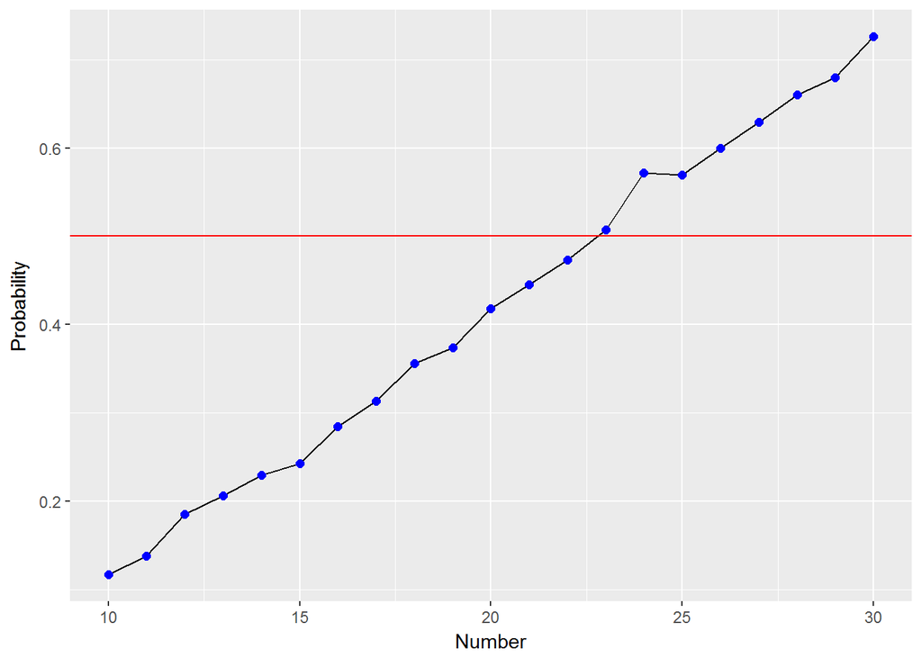

```r
iteration <- function(n, numofpeople){
    #We use 1 to 365 to represent the 365 days in a year. Now generate a series of 30 random number between 1 and 365 to represent the
    #birthdays of the 30 people
    birthdays <- sample(365, size=numofpeople,replace = TRUE)

    #Use rank function to rank the birthdays. If all birthdays are different, then rank will return 30 numbers from 1 to 30. Otherwise, it will return different
    #sequence of numbers. We use this property to tell if there is repeated birthdays.
    rank <- rank(birthdays, ties.method = "min")

    hasDuplication <- ifelse(sum(rank) == numofpeople*(numofpeople+1)/2, 0, 1)

    return(hasDuplication)
}

#We create a function to calculate probability with number of iterations as input
simulate <- function(iters,numofpeople) {
    results <- sapply(1:iters,iteration,numofpeople)
    prob <- sum(results) / iters
    return (prob)
}

#Create a function to calculate the error of the simulation model with the given number of iterations
SimError <- function(iters, numofpeople){
    prob1 <- simulate(iters,numofpeople)
    prob2 <- simulate(iters,numofpeople)

    return (abs(prob1-prob2))
}

GetDuplicateBirthDayProb <- function(numofpeople, threshold){
    #Now try to find out the desired probability
    num.iterations <- 1000

    while(num.iterations < 10000000) {
        error <- SimError(num.iterations,numofpeople)

        if(error < threshold)
            break

        num.iterations <- num.iterations *10
    }

    simulate(num.iterations,numofpeople)
}

probs<-sapply(10:30,GetDuplicateBirthDayProb,0.01)
df <- data.frame(Number = 10:30, Probability = probs)

library(ggplot2)
ggplot(df,aes(x=Number, y=Probability)) + geom_line() + geom_point(color='blue',size=2) + geom_abline(slope = 0, intercept = 0.5, color='red')
```

From the graph, we can tell that we just need 23 people to make the probability of having duplicated birthdays above 50%.

# Version 3

In the previous two versions, we ignore the possiblity of leap year so that we can use 365 across the whole simulation model. Now let’s try to make the model more realistic by taking the possibility of leap year into consideration. Can you try to enhance model 2 to achieve this?